# PRAMS Data Analysis: Iteration, Aggregation, & Transformation

Author

Erik Westlund

Published

June 11, 2025

```r
# Install required packages if not already installed
required_packages <- c("dplyr", "ggplot2", "forcats", "kableExtra", "readr", "ggtext")
new_packages <- required_packages[!(required_packages %in% installed.packages()[,"Package"])]
if(length(new_packages)) install.packages(new_packages)

# Load required packages
library(dplyr)
library(ggplot2)
library(forcats)
library(kableExtra)
library(readr)
library(ggtext)

source(here::here("examples", "colors.R"))
```

## Goal

In this file, we’ll show:

- How to iterate on a figure to make it more informative and visually appealing.
- The difference between using `stat = "identity"` and other statistical transformations.

## Research Question

Let’s examine the relationship between depression in the 3 months before birth and the number of previous live births, focusing specifically on Wisconsin.

## Data Preparation

First, let’s load and prepare our data:

```r
df_final <- readRDS(here::here("data", "processed", "cdc_prams_df_final.rds"))

# Filter for Wisconsin and relevant variables
df_wi <- df_final |>
  filter(
    location_abbr == "WI",
    subgroup_cat == "Number of Previous Live Births"
  ) |>
  select(
    location_abbr,
    subgroup,
    depression_within_3_months_birth
  )

# Let's look at the structure of our filtered data
df_wi |>
  glimpse()
```

```
Rows: 2
Columns: 3
$ location_abbr                    <fct> WI, WI
$ subgroup                         <chr> "0", "1 or more"
$ depression_within_3_months_birth <dbl> 13.8, 13.0
```

Let’s examine the unique values in our key variables:

```r
# Check unique values in depression variable
df_wi |>
  select(depression_within_3_months_birth) |>
  distinct() |>
  kable()
```

| depression_within_3_months_birth |
| --- |
| 13.8 |
| 13.0 |

```r
# Check unique values in subgroup (number of previous live births)
df_wi |>
  select(subgroup) |>
  distinct() |>
  kable()
```

| subgroup |
| --- |
| 0 |
| 1 or more |

Now let’s create our first visualization:

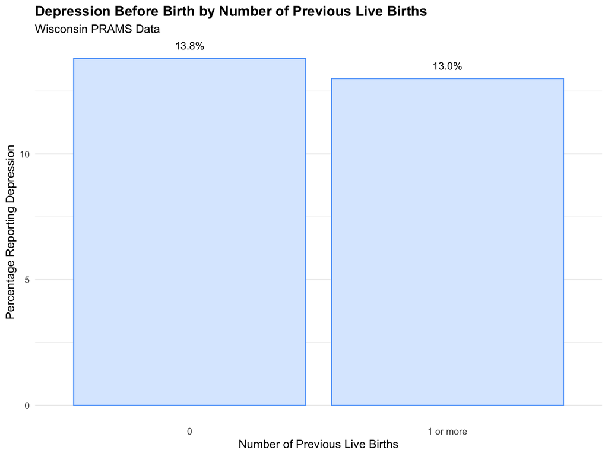

```r
p1 <- df_wi |>
  ggplot(aes(x = subgroup, y = depression_within_3_months_birth)) +
  geom_bar(
    stat = "identity",
    fill = colors$blue[['100']],
    color = colors$blue[['400']],
    linewidth = 0.5,
    linetype = "solid"
  ) +
  geom_text(
    aes(label = sprintf("%.1f%%", depression_within_3_months_birth)),
    vjust = -1.2,
    size = 3.5
  ) +
  theme_minimal() +
  labs(
    title = "Depression Before Birth by Number of Previous Live Births",
    subtitle = "Wisconsin PRAMS Data",
    x = "Number of Previous Live Births",
    y = "Percentage Reporting Depression"
  ) +
  theme(
    plot.title = element_text(face = "bold"),
    panel.grid.major.x = element_blank(),
    panel.grid.minor.x = element_blank()
  )

p1
```

## Faceting By Small Multiples

A great strategy for showing patterns by groups is to facet by small multiples.

Let’s start again with our data, not filtering by Wisconsin, but showing little bar charts for each state.

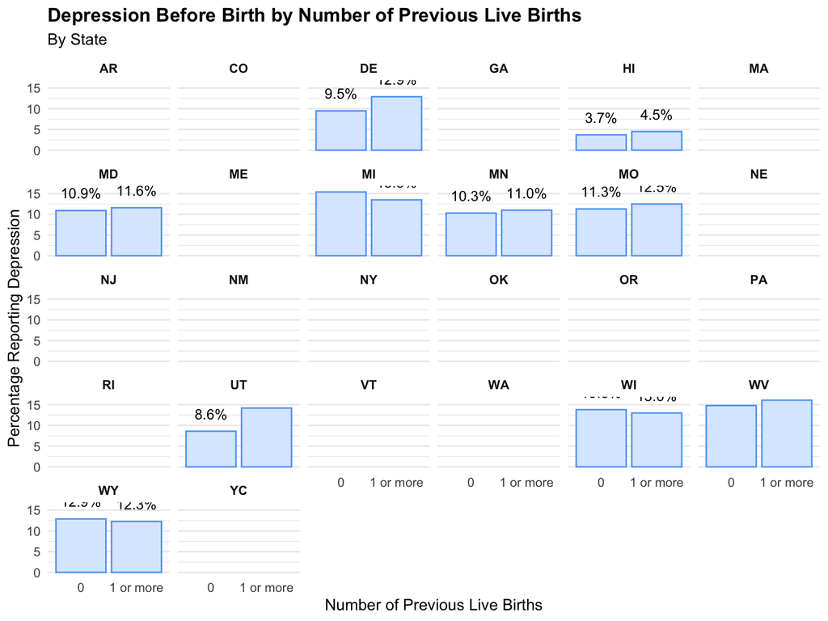

```r
p2 <- df_final |>
  filter(subgroup_cat == "Number of Previous Live Births") |>
  ggplot(aes(x = subgroup, y = depression_within_3_months_birth)) +
  geom_bar(
    stat = "identity",
    fill = colors$blue[['100']],
    color = colors$blue[['400']],
    linewidth = 0.5,
    linetype = "solid"
  ) +
  geom_text(
    aes(label = sprintf("%.1f%%", depression_within_3_months_birth)),
    vjust = -1.2,
    size = 3.5
  ) +
  facet_wrap(~ location_abbr) +
  theme_minimal() +
  labs(
    title = "Depression Before Birth by Number of Previous Live Births",
    subtitle = "By State",
    x = "Number of Previous Live Births",
    y = "Percentage Reporting Depression"
  ) +
  theme(
    plot.title = element_text(face = "bold"),
    panel.grid.major.x = element_blank(),
    panel.grid.minor.x = element_blank(),
    strip.text = element_text(face = "bold")
  )

p2
```

This a start. it has issues, though. First, we have a lot of missing states. Let’s fix that first.

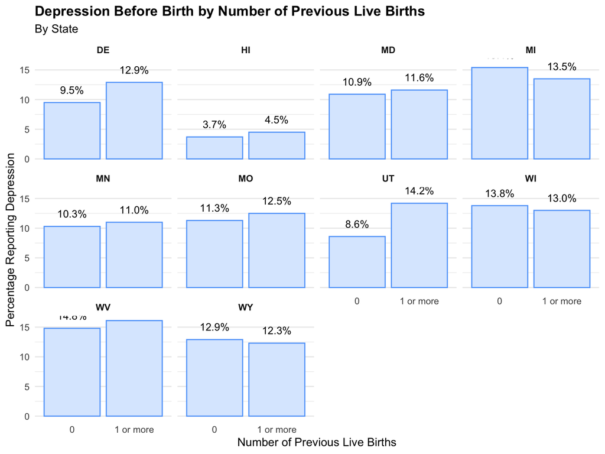

```r
p3 <- df_final |>
  filter(subgroup_cat == "Number of Previous Live Births") |>
  filter(!is.na(depression_within_3_months_birth)) |>
  ggplot(aes(x = subgroup, y = depression_within_3_months_birth)) +
  geom_bar(
    stat = "identity",
    fill = colors$blue[['100']],
    color = colors$blue[['400']],
    linewidth = 0.5,
    linetype = "solid"
  ) +
  geom_text(
    aes(label = sprintf("%.1f%%", depression_within_3_months_birth)),
    vjust = -1.2,
    size = 3.5
  ) +
  facet_wrap(~ location_abbr) +
  theme_minimal() +
  labs(
    title = "Depression Before Birth by Number of Previous Live Births",
    subtitle = "By State",
    x = "Number of Previous Live Births",
    y = "Percentage Reporting Depression"
  ) +
  theme(
    plot.title = element_text(face = "bold"),
    panel.grid.major.x = element_blank(),
    panel.grid.minor.x = element_blank(),
    strip.text = element_text(face = "bold")
  )

p3
```

This is an improvement, but we see some issues. First, our y-axis is too short, and annotations are getting cut off. We can fix our y axis to go to 20

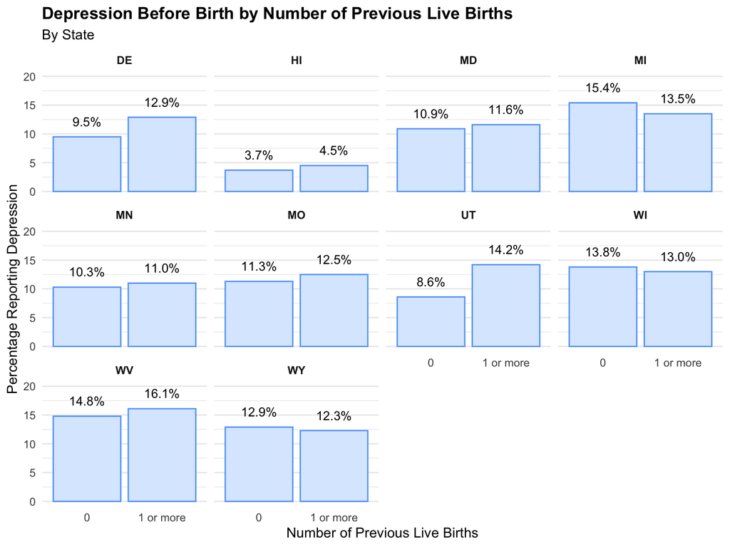

```r
p4 <- p3 +
  scale_y_continuous(limits = c(0, 20))

p4
```

That’s better. Some stylistic adjustments:

- Need more space between the labels and the plot:

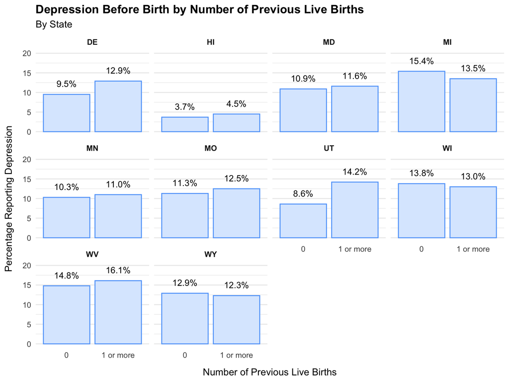

```r
p5 <- p4 +
  theme(
    axis.title.x = element_text(margin = margin(t = 10)),
    axis.title.y = element_text(margin = margin(r = 10))
  )

p5
```

Now, let’s sort it by the *difference* between the birth. This requires data transformation, so we’ll start from scratch.

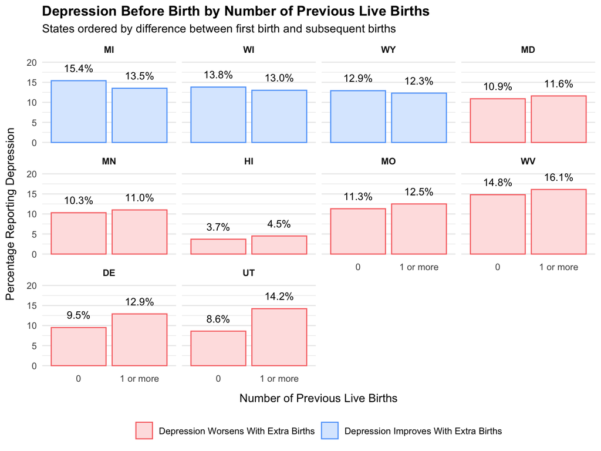

```r
# Calculate differences and sort states
state_diffs <- df_final |>
  filter(subgroup_cat == "Number of Previous Live Births") |>
  filter(!is.na(depression_within_3_months_birth)) |>
  group_by(location_abbr) |>
  summarize(
    first_birth = depression_within_3_months_birth[subgroup == "0"],
    later_births = mean(depression_within_3_months_birth[subgroup != "0"]),
    diff = first_birth - later_births
  ) |>
  arrange(desc(diff))

# Create ordered factor for states
state_order <- state_diffs$location_abbr

# Create plot with sorted states
p6 <- df_final |>
  filter(subgroup_cat == "Number of Previous Live Births") |>
  filter(!is.na(depression_within_3_months_birth)) |>
  mutate(location_abbr = factor(location_abbr, levels = state_order)) |>
  left_join(
    state_diffs |> select(location_abbr, diff),
    by = "location_abbr"
  ) |>
  ggplot(aes(x = subgroup, y = depression_within_3_months_birth)) +
  geom_bar(
    stat = "identity",
    aes(fill = diff > 0, color = diff > 0),
    linewidth = 0.5,
    linetype = "solid"
  ) +
  scale_fill_manual(
    name = "Difference",
    values = c(
      "TRUE" = colors$blue[['100']],
      "FALSE" = colors$red[['100']]
    ),
    labels = c(
      "TRUE" = "Depression Improves With Extra Births",
      "FALSE" = "Depression Worsens With Extra Births"
    )
  ) +
  scale_color_manual(
    name = "Difference",
    values = c(
      "TRUE" = colors$blue[['400']],
      "FALSE" = colors$red[['400']]
    ),
    labels = c(
      "TRUE" = "Depression Improves With Extra Births",
      "FALSE" = "Depression Worsens With Extra Births"
    )
  ) +
  geom_text(
    aes(label = sprintf("%.1f%%", depression_within_3_months_birth)),
    vjust = -1.2,
    size = 3.5
  ) +
  facet_wrap(~ location_abbr) +
  scale_y_continuous(limits = c(0, 20)) +
  theme_minimal() +
  labs(
    title = "Depression Before Birth by Number of Previous Live Births",
    subtitle = "States ordered by difference between first birth and subsequent births",
    x = "Number of Previous Live Births",
    y = "Percentage Reporting Depression"
  ) +
  theme(
    plot.title = element_text(face = "bold"),
    panel.grid.major.x = element_blank(),
    panel.grid.minor.x = element_blank(),
    strip.text = element_text(face = "bold"),
    axis.title.x = element_text(margin = margin(t = 10)),
    axis.title.y = element_text(margin = margin(r = 10)),
    legend.position = "bottom",
    legend.title = element_blank()
  )

p6
```

This is interesting, but I wonder if we’re using the right graph.

If we’re interested in the *difference*, we can do a forest plot by state in a single plot. Let’s start with a basic version.

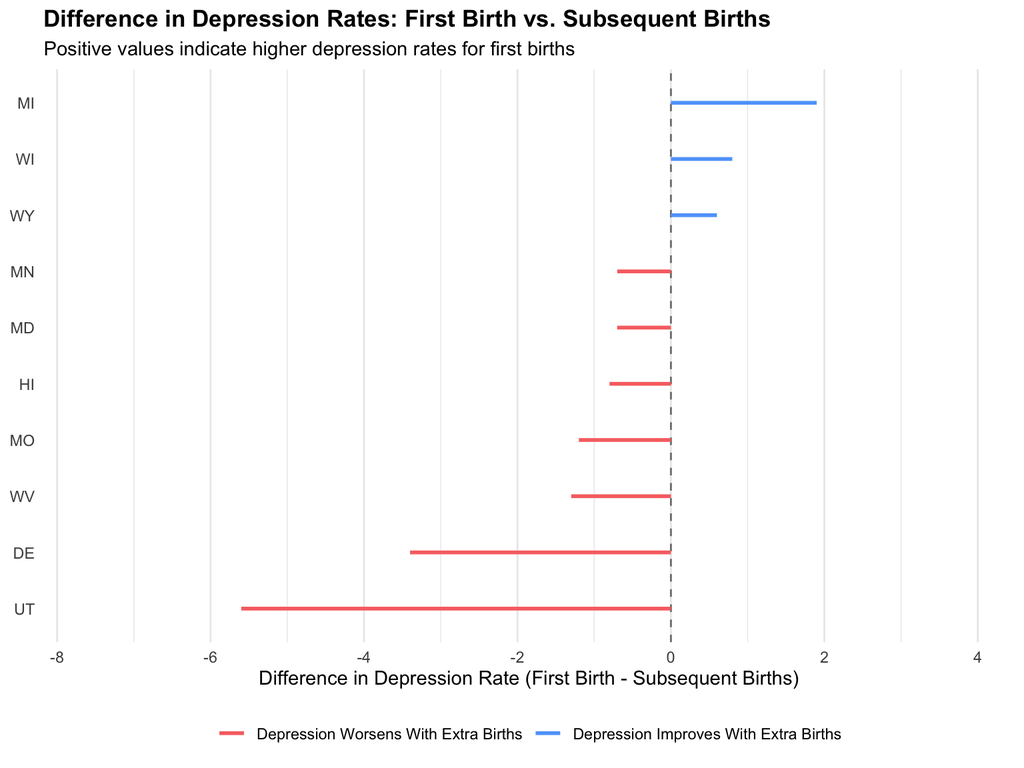

```r
# Calculate differences for forest plot
forest_data <- df_final |>
  filter(subgroup_cat == "Number of Previous Live Births") |>
  filter(!is.na(depression_within_3_months_birth)) |>
  group_by(location_abbr) |>
  summarize(
    first_birth = depression_within_3_months_birth[subgroup == "0"],
    later_births = mean(depression_within_3_months_birth[subgroup != "0"]),
    diff = first_birth - later_births
  ) |>
  arrange(diff)  # Sort by difference

# Create ordered factor for states
state_order <- forest_data$location_abbr

# Create forest plot
p7 <- forest_data |>
  mutate(location_abbr = factor(location_abbr, levels = state_order)) |>
  ggplot(aes(x = diff, y = location_abbr)) +
  geom_vline(xintercept = 0, linetype = "dashed", color = "gray50") +
  geom_segment(
    aes(
      x = 0,
      xend = diff,
      y = location_abbr,
      yend = location_abbr,
      color = diff > 0
    ),
    linewidth = 1
  ) +
  scale_color_manual(
    values = c(
      "TRUE" = colors$blue[['400']],
      "FALSE" = colors$red[['400']]
    ),
    labels = c(
      "TRUE" = "Depression Improves With Extra Births",
      "FALSE" = "Depression Worsens With Extra Births"
    )
  ) +
  scale_x_continuous(
    limits = c(min(forest_data$diff) - 2, max(forest_data$diff) + 2),
    breaks = seq(-10, 10, 2)
  ) +
  theme_minimal() +
  labs(
    title = "Difference in Depression Rates: First Birth vs. Subsequent Births",
    subtitle = "Positive values indicate higher depression rates for first births",
    x = "Difference in Depression Rate (First Birth - Subsequent Births)",
    y = NULL
  ) +
  theme(
    plot.title = element_text(face = "bold"),
    panel.grid.major.y = element_blank(),
    panel.grid.minor.y = element_blank(),
    legend.position = "bottom",
    legend.title = element_blank()
  )

p7
```

This is a decent start. Let’s add text annotations to the plot. Let’s also use the `location` rather than the abbrevaition.

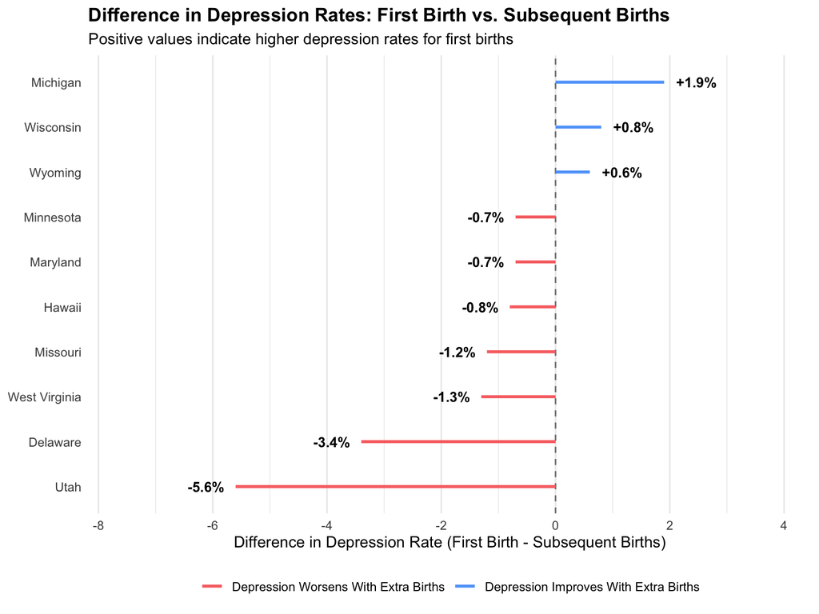

```r
# Calculate differences for forest plot
forest_data <- df_final |>
  filter(subgroup_cat == "Number of Previous Live Births") |>
  filter(!is.na(depression_within_3_months_birth)) |>
  group_by(location_abbr, location) |>
  summarize(
    first_birth = depression_within_3_months_birth[subgroup == "0"],
    later_births = mean(depression_within_3_months_birth[subgroup != "0"]),
    diff = first_birth - later_births,
    .groups = "drop"
  ) |>
  arrange(diff)  # Sort by difference

# Create ordered factor for states
state_order <- forest_data$location

# Create forest plot
p8 <- forest_data |>
  mutate(location = factor(location, levels = state_order)) |>
  ggplot(aes(x = diff, y = location)) +
  geom_vline(xintercept = 0, linetype = "dashed", color = "gray50") +
  geom_segment(
    aes(
      x = 0,
      xend = diff,
      y = location,
      yend = location,
      color = diff > 0
    ),
    linewidth = 1
  ) +
  geom_text(
    aes(
      x = diff,
      label = sprintf("%+.1f%%", diff)
    ),
    hjust = ifelse(forest_data$diff > 0, -0.3, 1.3),
    size = 3.5,
    fontface = "bold"
  ) +
  scale_color_manual(
    values = c(
      "TRUE" = colors$blue[['400']],
      "FALSE" = colors$red[['400']]
    ),
    labels = c(
      "TRUE" = "Depression Improves With Extra Births",
      "FALSE" = "Depression Worsens With Extra Births"
    )
  ) +
  scale_x_continuous(
    limits = c(min(forest_data$diff) - 2, max(forest_data$diff) + 2),
    breaks = seq(-10, 10, 2)
  ) +
  theme_minimal() +
  labs(
    title = "Difference in Depression Rates: First Birth vs. Subsequent Births",
    subtitle = "Positive values indicate higher depression rates for first births",
    x = "Difference in Depression Rate (First Birth - Subsequent Births)",
    y = NULL
  ) +
  theme(
    plot.title = element_text(face = "bold"),
    panel.grid.major.y = element_blank(),
    panel.grid.minor.y = element_blank(),
    legend.position = "bottom",
    legend.title = element_blank()
  )

p8
```

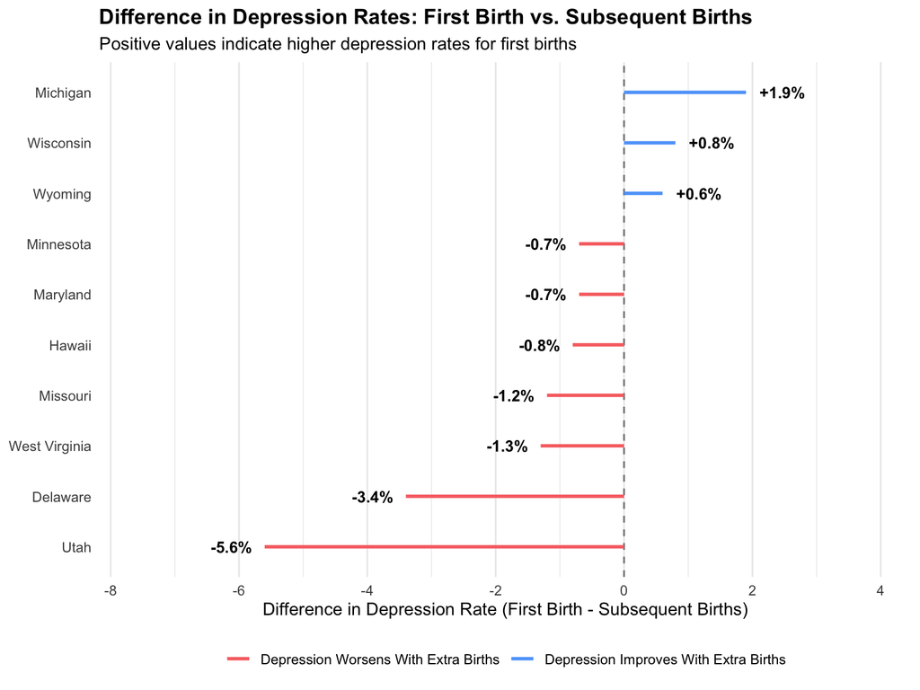

```r
p9 <- forest_data |>
  mutate(location = factor(location, levels = state_order)) |>
  ggplot(aes(x = diff, y = location)) +
  geom_vline(xintercept = 0, linetype = "dashed", color = "gray50") +
  geom_segment(
    aes(
      x = 0,
      xend = diff,
      y = location,
      yend = location,
      color = diff > 0
    ),
    linewidth = 1
  ) +
  geom_text(
    aes(
      x = diff,
      label = sprintf("%+.1f%%", diff)
    ),
    hjust = ifelse(forest_data$diff > 0, -0.3, 1.3),
    size = 3.5,
    fontface = "bold"
  ) +
  scale_color_manual(
    values = c(
      "TRUE" = colors$blue[['400']],
      "FALSE" = colors$red[['400']]
    ),
    labels = c(
      "TRUE" = "Depression Improves With Extra Births",
      "FALSE" = "Depression Worsens With Extra Births"
    )
  ) +
  scale_x_continuous(
    limits = c(min(forest_data$diff) - 2, max(forest_data$diff) + 2),
    breaks = seq(-10, 10, 2)
  ) +
  theme_minimal() +
  labs(
    title = "Difference in Depression Rates: First Birth vs. Subsequent Births",
    subtitle = "Positive values indicate higher depression rates for first births",
    x = "Difference in Depression Rate (First Birth - Subsequent Births)",
    y = NULL
  ) +
  theme(
    plot.title = element_text(face = "bold"),
    panel.grid.major.y = element_blank(),
    panel.grid.minor.y = element_blank(),
    legend.position = "bottom",
    legend.title = element_blank()
  )

p9
```

Let’s step back and think.

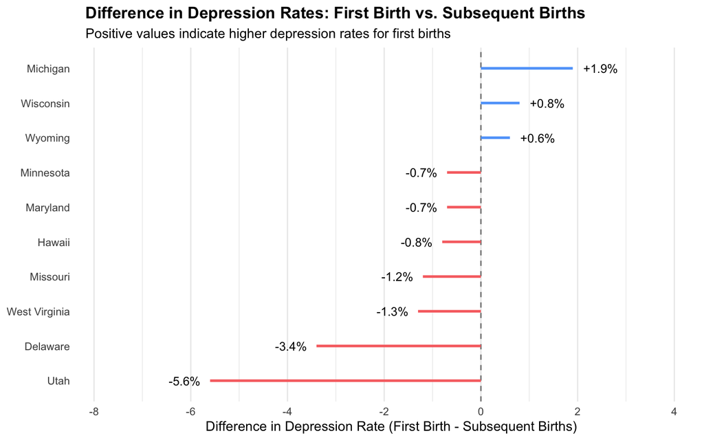

```r
p10 <- forest_data |>
  mutate(location = factor(location, levels = state_order)) |>
  ggplot(aes(x = diff, y = location)) +
  geom_vline(xintercept = 0, linetype = "dashed", color = "gray50") +
  geom_segment(
    aes(
      x = 0,
      xend = diff,
      y = location,
      yend = location,
      color = ifelse(diff > 0, "positive", "negative")
    ),
    linewidth = 1
  ) +
  geom_text(
    aes(
      x = diff,
      label = sprintf("%+.1f%%", diff)
    ),
    hjust = ifelse(forest_data$diff > 0, -0.3, 1.3),
    size = 3.5
  ) +
  scale_color_manual(
    values = c(
      "positive" = colors$blue[['400']],
      "negative" = colors$red[['400']]
    )
  ) +
  scale_x_continuous(
    limits = c(min(forest_data$diff) - 2, max(forest_data$diff) + 2),
    breaks = seq(-10, 10, 2)
  ) +
  theme_minimal() +
  labs(
    title = "Difference in Depression Rates: First Birth vs. Subsequent Births",
    subtitle = "Positive values indicate higher depression rates for first births",
    x = "Difference in Depression Rate (First Birth - Subsequent Births)",
    y = NULL
  ) +
  theme(
    plot.title = element_text(face = "bold"),
    panel.grid.major.y = element_blank(),
    panel.grid.minor.y = element_blank(),
    legend.position = "none",
    axis.text.y = element_text(margin = margin(r = 10))
  )

p10
```

## Thinking About Aggregations & Transformations

Let’s create a simulated dataset to illustrate how we were using `stat = "identity"` above. We’ll create individual-level data that mimics our PRAMS data structure.

```r
# Set seed for reproducibility
set.seed(123)

# Create simulated data
sim_data <- tibble(
  state = rep(state.name, each = 100)  # 100 people per state
) |>
  mutate(
    person_id = row_number(),  # Generate unique IDs
    # Generate number of previous births using Poisson distribution (mean = 1)
    previous_births_count = rpois(n(), lambda = 1),
    # Create factor for 0 vs 1+ births
    previous_births = factor(
      ifelse(previous_births_count == 0, "0", "1+"),
      levels = c("0", "1+")
    ),

    # Generate depression status with different probabilities based on previous births
    # Higher probability of depression for first births (0) than subsequent births (1+)
    depression_prob = ifelse(previous_births == "0", 0.15, 0.10),  # 15% vs 10% base rates
    depression = rbinom(n(), 1, depression_prob) == 1  # Convert to TRUE/FALSE
  ) |>
  select(-depression_prob)

# Let's look at the structure
sim_data |>
  glimpse()
```

```
Rows: 5,000
Columns: 5
$ state                 <chr> "Alabama", "Alabama", "Alabama", "Alabama", "Ala…
$ person_id             <int> 1, 2, 3, 4, 5, 6, 7, 8, 9, 10, 11, 12, 13, 14, 1…
$ previous_births_count <int> 0, 2, 1, 2, 3, 0, 1, 2, 1, 1, 3, 1, 1, 1, 0, 2, …
$ previous_births       <fct> 0, 1+, 1+, 1+, 1+, 0, 1+, 1+, 1+, 1+, 1+, 1+, 1+…
$ depression            <lgl> FALSE, TRUE, FALSE, FALSE, FALSE, FALSE, FALSE, …
```

```r
sim_data |>
  head() |>
  kable()
```

| state | person_id | previous_births_count | previous_births | depression |
| --- | --- | --- | --- | --- |
| Alabama | 1 | 0 | 0 | FALSE |
| Alabama | 2 | 2 | 1+ | TRUE |
| Alabama | 3 | 1 | 1+ | FALSE |
| Alabama | 4 | 2 | 1+ | FALSE |
| Alabama | 5 | 3 | 1+ | FALSE |
| Alabama | 6 | 0 | 0 | FALSE |

```r
# Quick summary to verify our data
sim_data |>
  group_by(state, previous_births) |>
  summarize(
    n = n(),
    depression_rate = mean(depression) * 100,
    .groups = "drop"
  ) |>
  head() |>
  kable()
```

| state | previous_births | n | depression_rate |
| --- | --- | --- | --- |
| Alabama | 0 | 35 | 20.000000 |
| Alabama | 1+ | 65 | 12.307692 |
| Alaska | 0 | 33 | 18.181818 |
| Alaska | 1+ | 67 | 5.970149 |
| Arizona | 0 | 39 | 15.384615 |
| Arizona | 1+ | 61 | 6.557377 |

## Recreating Visualizations with Simulated Data

Let’s recreate our visualizations using the simulated data, starting with Wisconsin.

Below we are using the `stat = "summary"` to aggregate the data and the `scales` functionality to format the y axis as a percentage.

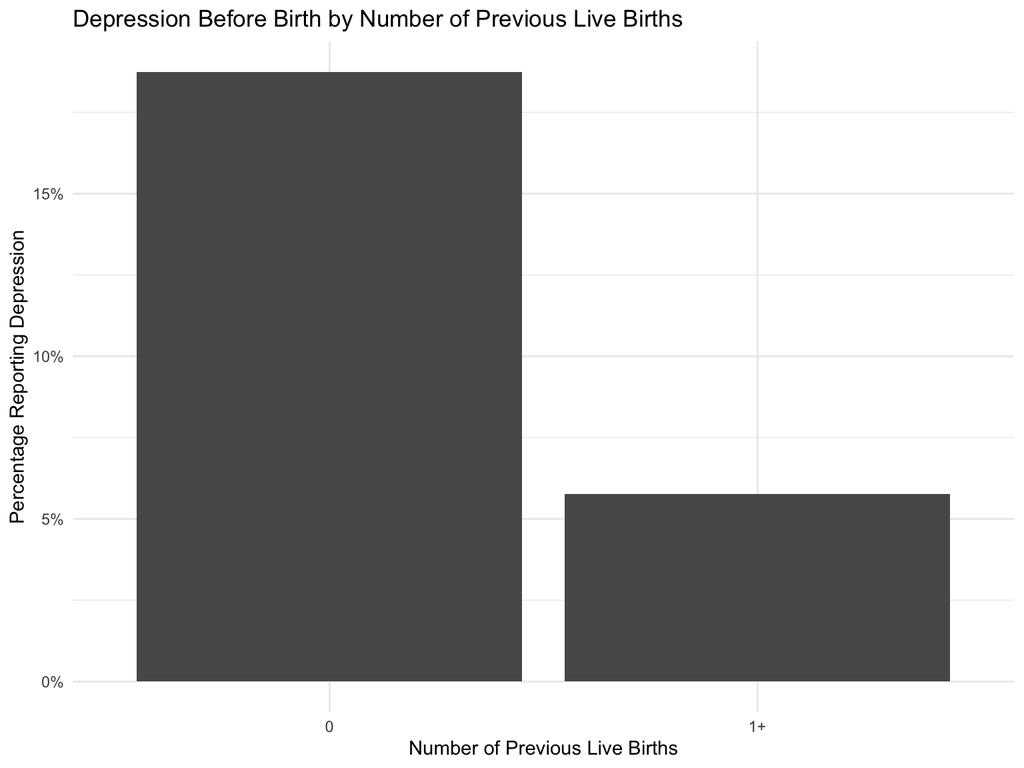

```r
# Filter for Wisconsin
wi_data <- sim_data |>
  filter(state == "Wisconsin") |>
  mutate(depression = as.numeric(depression))

# Approach 1: Using scales::percent_format()
p1_sim <- wi_data |>
  ggplot(aes(x = previous_births, y = depression)) +
  geom_bar(
    stat = "summary",  # We let ggplot2 do the aggregation for us
    fun = "mean"
  ) +
  scale_y_continuous(labels = scales::percent_format()) +
  theme_minimal() +
  labs(
    title = "Depression Before Birth by Number of Previous Live Births",
    x = "Number of Previous Live Births",
    y = "Percentage Reporting Depression"
  )

p1_sim
```

An alternative approach is – similar to above – is to do the aggregation ourselves and use identity.

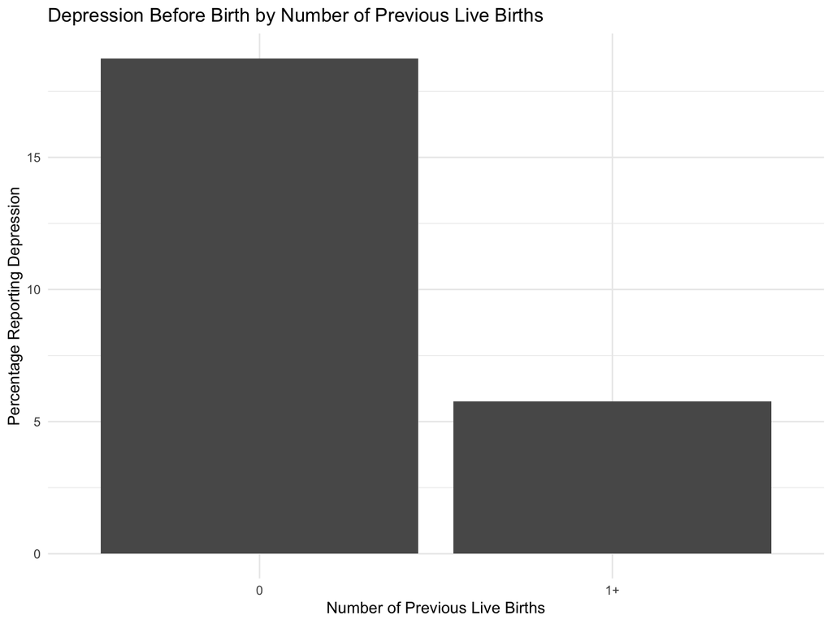

```r
# Approach 2: Multiplying by 100 in the aggregation
p1_sim_self_aggregate <- wi_data |>
  group_by(previous_births) |>
  summarize(
    depression_rate = mean(depression) * 100,  # Convert to percentage
    .groups = "drop"
  ) |>
  ggplot(aes(x = previous_births, y = depression_rate)) +
  geom_bar(stat = "identity") +
  theme_minimal() +
  labs(
    title = "Depression Before Birth by Number of Previous Live Births",
    x = "Number of Previous Live Births",
    y = "Percentage Reporting Depression"
  )

# Display both plots

p1_sim_self_aggregate
```

Life tends to be easier when you summarize the data yourself. I find it more explicit and it avoids confusion from trying to figure out exactly what `ggplot2` is doing.